# Bootstrap Example

```r
x<-c(1:100)
B<-100
p_boot <- numeric(B)
for(b in 1:B) {
  ## Take bootstrap sample and record the win proportion.
  p_boot[b] <- mean(sample(x, replace = TRUE))
}
```

```r
p_boot
```

1. 52.21

2. 48.87

3. 52.57

4. 54.18

5. 47.46

6. 52.89

7. 52.28

8. 45.08

9. 50.94

10. 41.49

11. 52.73

12. 49.42

13. 51.37

14. 56.16

15. 47.75

16. 50.12

17. 51.24

18. 54.35

19. 47.33

20. 50.23

21. 47.66

22. 48.63

23. 50.27

24. 53.45

25. 51.17

26. 49.63

27. 53.66

28. 48.48

29. 46.57

30. 51.14

31. 52.36

32. 49.77

33. 49.99

34. 47.74

35. 50.33

36. 46.82

37. 53.29

38. 50.2

39. 50.8

40. 54.8

41. 50.4

42. 51.57

43. 50.9

44. 49.88

45. 56.91

46. 52.41

47. 49.39

48. 52.06

49. 55.62

50. 49.25

51. 47.03

52. 51.64

53. 53.16

54. 47.93

55. 53.62

56. 44.43

57. 54.43

58. 53.86

59. 45.42

60. 46.91

61. 51.54

62. 49.22

63. 56.04

64. 54.21

65. 49.46

66. 51.61

67. 53.81

68. 45.99

69. 49.98

70. 46.08

71. 50.63

72. 47.02

73. 48.36

74. 53.48

75. 46.2

76. 48.53

77. 50.23

78. 50.96

79. 48.2

80. 47.32

81. 55.18

82. 51.23

83. 51.49

84. 57.82

85. 54.09

86. 51.41

87. 49.24

88. 52.42

89. 51.15

90. 53.05

91. 51.94

92. 50.64

93. 50.05

94. 55.52

95. 51.58

96. 49.85

97. 49.04

98. 45.17

99. 48.45

100. 54.03

```r
mean(p_boot)
```

50.6447

```r
mean(x)
```

50.5

# Illustrative Example

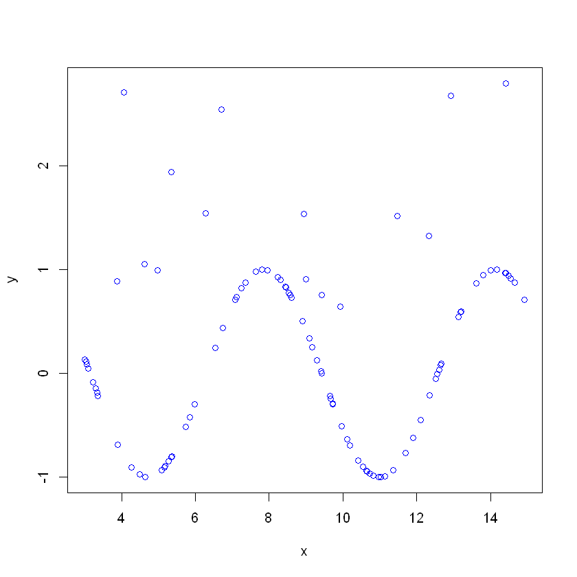

```r
### Generate Data
x<-3*runif(100,1,5)
y<-sin(x)
### Add some noise
noise_sample <- sample(1:length(y),15)
y[noise_sample]= 2*(0.5 - runif(15,-1,0.3))
df<-cbind(x,y)
df<-data.frame(df)
plot(y~x,col="blue")
```

```
node), split, n, deviance, yval
      * denotes terminal node

 1) root 100 82.4300  0.24960
   2) x < 12.7883 84 62.6800  0.09127
     4) x < 9.53549 55 41.0500  0.33580
       8) x < 6.13105 27 22.5700 -0.12870
        16) x < 4.17296 11  8.1060  0.23960 *
        17) x > 4.17296 16 11.9500 -0.38190 *
       9) x > 6.13105 28  7.0340  0.78370
        18) x < 9.03951 22  4.4500  0.92980 *
        19) x > 9.03951 6  0.3925  0.24810 *
     5) x > 9.53549 29 12.1100 -0.37250
      10) x < 11.4208 18  3.2000 -0.65180
        20) x < 9.9394 5  0.6552 -0.08283 *
        21) x > 9.9394 13  0.3032 -0.87070 *
      11) x > 11.4208 11  5.2070  0.08463 *
   3) x > 12.7883 16  6.5850  1.08100 *
```

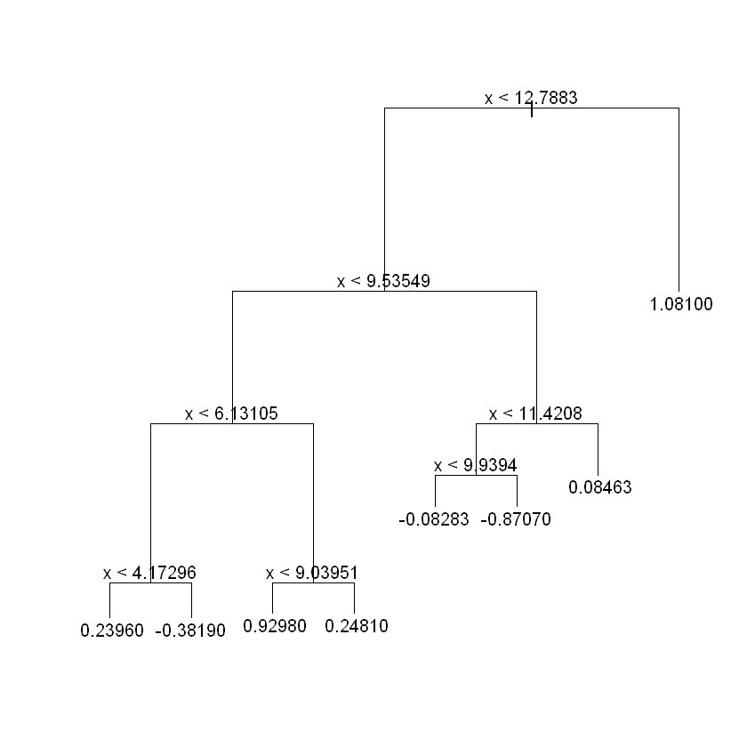

```r
library(tree)
require(randomForest)
tree.df = tree(y~.,df)
prune.df =prune.tree(tree.df ,best =3)
rf.df =randomForest(y~.,df)
yhat.rf=predict (rf.df ,newdata =df)
yhat.tree=predict (tree.df ,newdata =df)
plot(tree.df)
text(tree.df,pretty =0)
tree.df
```

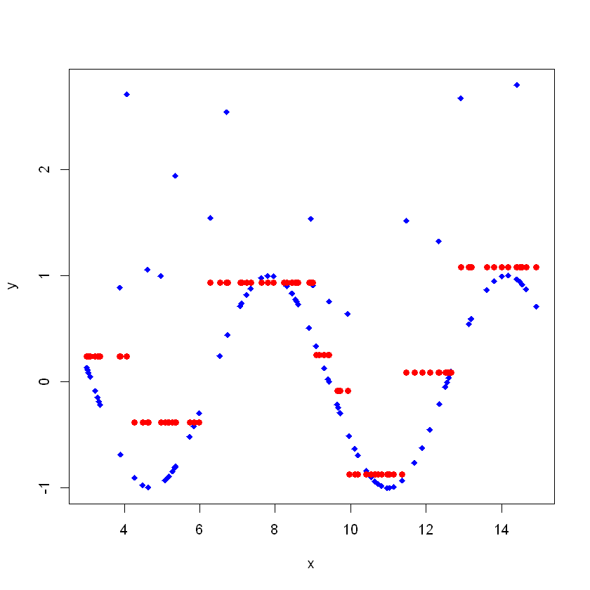

```r
plot(y~x,col="blue",pch=18)
points(yhat.tree~x,col="red",pch=19)
#points(yhat.rf~x,col="green",pch=20)
#legend("bottomleft",legend=c("y","Tree-y","RF-Y"),
 #      col=c("blue","red","green"),pch=18:19)
```

```
node), split, n, deviance, yval
      * denotes terminal node

 1) root 100 82.4300  0.24960
   2) x < 12.7883 84 62.6800  0.09127
     4) x < 9.53549 55 41.0500  0.33580
       8) x < 6.13105 27 22.5700 -0.12870
        16) x < 4.17296 11  8.1060  0.23960 *
        17) x > 4.17296 16 11.9500 -0.38190 *
       9) x > 6.13105 28  7.0340  0.78370
        18) x < 9.03951 22  4.4500  0.92980 *
        19) x > 9.03951 6  0.3925  0.24810 *
     5) x > 9.53549 29 12.1100 -0.37250
      10) x < 11.4208 18  3.2000 -0.65180
        20) x < 9.9394 5  0.6552 -0.08283 *
        21) x > 9.9394 13  0.3032 -0.87070 *
      11) x > 11.4208 11  5.2070  0.08463 *
   3) x > 12.7883 16  6.5850  1.08100 *
```

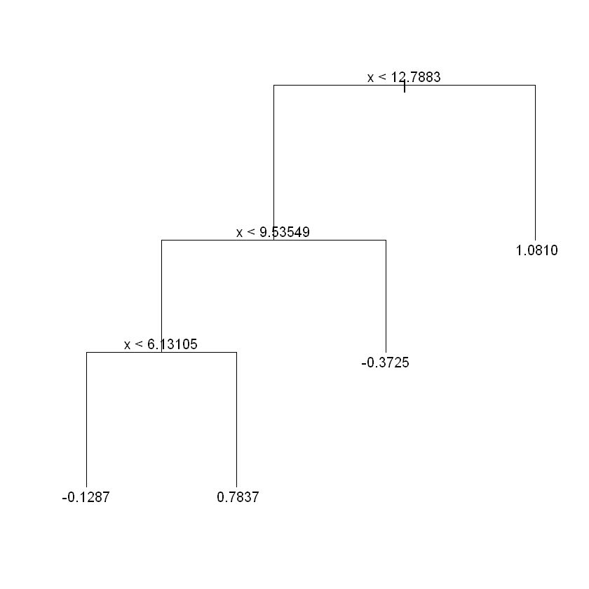

```r
prune.df =prune.tree(tree.df ,best =3)
yhat.tree.p=predict (prune.df ,newdata =df)
plot(prune.df)
text(prune.df,pretty =0)
tree.df
```

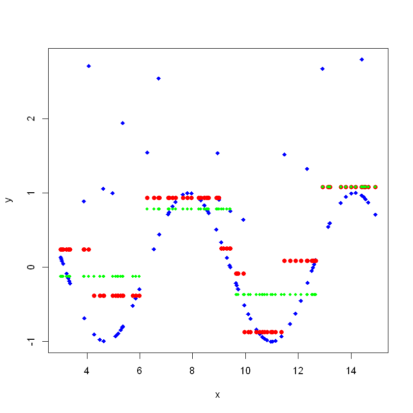

```r
plot(y~x,col="blue",pch=18)
points(yhat.tree~x,col="red",pch=19)
points(yhat.tree.p~x,col="green",pch=20)
```

# Data Analysis

In this section we are going to use tree based methods to predict the medium house price. We are going to use Boston house prices dataset. This data frame contains the following columns:

- `crim` -per capita crime rate by town.
- `zn` -proportion of residential land zoned for lots over 25,000 sq.ft.
- `indus` - proportion of non-retail business acres per town.
- `chas` - Charles River dummy variable (= 1 if tract bounds river; 0 otherwise).
- `nox` -nitrogen oxides concentration (parts per 10 million).
- `rm`- average number of rooms per dwelling.
- `age` - proportion of owner-occupied units built prior to 1940.
- `dis` - weighted mean of distances to five Boston employment centres.
- `rad` - index of accessibility to radial highways.
- `tax` - full-value property-tax rate per $\$10,000$.
- `ptratio` - pupil-teacher ratio by town.
- `black` - $1000(Bk−0.63)^2$ where Bk is the proportion of blacks by town.
- `lstat` - lower status of the population (percent).
- `medv` - median value of owner-occupied homes in $1000s.

The `tree` library is used to construct classification and regression trees.

```r
#install.packages("tree")
library(tree)
```

Here we fit a regression tree to the `Boston` dataset.

```r
library(MASS)
head(Boston)
```

| crim | zn | indus | chas | nox | rm | age | dis | rad | tax | ptratio | black | lstat | medv |
| --- | --- | --- | --- | --- | --- | --- | --- | --- | --- | --- | --- | --- | --- |
| 0.00632 | 18 | 2.31 | 0 | 0.538 | 6.575 | 65.2 | 4.0900 | 1 | 296 | 15.3 | 396.90 | 4.98 | 24.0 |
| 0.02731 | 0 | 7.07 | 0 | 0.469 | 6.421 | 78.9 | 4.9671 | 2 | 242 | 17.8 | 396.90 | 9.14 | 21.6 |
| 0.02729 | 0 | 7.07 | 0 | 0.469 | 7.185 | 61.1 | 4.9671 | 2 | 242 | 17.8 | 392.83 | 4.03 | 34.7 |
| 0.03237 | 0 | 2.18 | 0 | 0.458 | 6.998 | 45.8 | 6.0622 | 3 | 222 | 18.7 | 394.63 | 2.94 | 33.4 |
| 0.06905 | 0 | 2.18 | 0 | 0.458 | 7.147 | 54.2 | 6.0622 | 3 | 222 | 18.7 | 396.90 | 5.33 | 36.2 |
| 0.02985 | 0 | 2.18 | 0 | 0.458 | 6.430 | 58.7 | 6.0622 | 3 | 222 | 18.7 | 394.12 | 5.21 | 28.7 |

Check missing values

```r
sum(is.na(Boston))
```

0

```r
dim(Boston)
```

1. 506

2. 14

```r
summary(Boston)
```

```
      crim                zn             indus            chas
 Min.   : 0.00632   Min.   :  0.00   Min.   : 0.46   Min.   :0.00000
 1st Qu.: 0.08204   1st Qu.:  0.00   1st Qu.: 5.19   1st Qu.:0.00000
 Median : 0.25651   Median :  0.00   Median : 9.69   Median :0.00000
 Mean   : 3.61352   Mean   : 11.36   Mean   :11.14   Mean   :0.06917
 3rd Qu.: 3.67708   3rd Qu.: 12.50   3rd Qu.:18.10   3rd Qu.:0.00000
 Max.   :88.97620   Max.   :100.00   Max.   :27.74   Max.   :1.00000
      nox               rm             age              dis
 Min.   :0.3850   Min.   :3.561   Min.   :  2.90   Min.   : 1.130
 1st Qu.:0.4490   1st Qu.:5.886   1st Qu.: 45.02   1st Qu.: 2.100
 Median :0.5380   Median :6.208   Median : 77.50   Median : 3.207
 Mean   :0.5547   Mean   :6.285   Mean   : 68.57   Mean   : 3.795
 3rd Qu.:0.6240   3rd Qu.:6.623   3rd Qu.: 94.08   3rd Qu.: 5.188
 Max.   :0.8710   Max.   :8.780   Max.   :100.00   Max.   :12.127
      rad              tax           ptratio          black
 Min.   : 1.000   Min.   :187.0   Min.   :12.60   Min.   :  0.32
 1st Qu.: 4.000   1st Qu.:279.0   1st Qu.:17.40   1st Qu.:375.38
 Median : 5.000   Median :330.0   Median :19.05   Median :391.44
 Mean   : 9.549   Mean   :408.2   Mean   :18.46   Mean   :356.67
 3rd Qu.:24.000   3rd Qu.:666.0   3rd Qu.:20.20   3rd Qu.:396.23
 Max.   :24.000   Max.   :711.0   Max.   :22.00   Max.   :396.90
     lstat            medv
 Min.   : 1.73   Min.   : 5.00
 1st Qu.: 6.95   1st Qu.:17.02
 Median :11.36   Median :21.20
 Mean   :12.65   Mean   :22.53
 3rd Qu.:16.95   3rd Qu.:25.00
 Max.   :37.97   Max.   :50.00
```

```r
Boston$chas
```

1. 0

2. 0

3. 0

4. 0

5. 0

6. 0

7. 0

8. 0

9. 0

10. 0

11. 0

12. 0

13. 0

14. 0

15. 0

16. 0

17. 0

18. 0

19. 0

20. 0

21. 0

22. 0

23. 0

24. 0

25. 0

26. 0

27. 0

28. 0

29. 0

30. 0

31. 0

32. 0

33. 0

34. 0

35. 0

36. 0

37. 0

38. 0

39. 0

40. 0

41. 0

42. 0

43. 0

44. 0

45. 0

46. 0

47. 0

48. 0

49. 0

50. 0

51. 0

52. 0

53. 0

54. 0

55. 0

56. 0

57. 0

58. 0

59. 0

60. 0

61. 0

62. 0

63. 0

64. 0

65. 0

66. 0

67. 0

68. 0

69. 0

70. 0

71. 0

72. 0

73. 0

74. 0

75. 0

76. 0

77. 0

78. 0

79. 0

80. 0

81. 0

82. 0

83. 0

84. 0

85. 0

86. 0

87. 0

88. 0

89. 0

90. 0

91. 0

92. 0

93. 0

94. 0

95. 0

96. 0

97. 0

98. 0

99. 0

100. 0

101. 0

102. 0

103. 0

104. 0

105. 0

106. 0

107. 0

108. 0

109. 0

110. 0

111. 0

112. 0

113. 0

114. 0

115. 0

116. 0

117. 0

118. 0

119. 0

120. 0

121. 0

122. 0

123. 0

124. 0

125. 0

126. 0

127. 0

128. 0

129. 0

130. 0

131. 0

132. 0

133. 0

134. 0

135. 0

136. 0

137. 0

138. 0

139. 0

140. 0

141. 0

142. 0

143. 1

144. 0

145. 0

146. 0

147. 0

148. 0

149. 0

150. 0

151. 0

152. 0

153. 1

154. 0

155. 1

156. 1

157. 0

158. 0

159. 0

160. 0

161. 1

162. 0

163. 1

164. 1

165. 0

166. 0

167. 0

168. 0

169. 0

170. 0

171. 0

172. 0

173. 0

174. 0

175. 0

176. 0

177. 0

178. 0

179. 0

180. 0

181. 0

182. 0

183. 0

184. 0

185. 0

186. 0

187. 0

188. 0

189. 0

190. 0

191. 0

192. 0

193. 0

194. 0

195. 0

196. 0

197. 0

198. 0

199. 0

200. 0

201. 0

202. 0

203. 0

204. 0

205. 0

206. 0

207. 0

208. 0

209. 1

210. 1

211. 1

212. 1

213. 1

214. 0

215. 0

216. 0

217. 1

218. 0

219. 1

220. 1

221. 1

222. 1

223. 1

224. 0

225. 0

226. 0

227. 0

228. 0

229. 0

230. 0

231. 0

232. 0

233. 0

234. 0

235. 1

236. 0

237. 1

238. 0

239. 0

240. 0

241. 0

242. 0

243. 0

244. 0

245. 0

246. 0

247. 0

248. 0

249. 0

250. 0

251. 0

252. 0

253. 0

254. 0

255. 0

256. 0

257. 0

258. 0

259. 0

260. 0

261. 0

262. 0

263. 0

264. 0

265. 0

266. 0

267. 0

268. 0

269. 0

270. 1

271. 0

272. 0

273. 0

274. 1

275. 1

276. 0

277. 1

278. 1

279. 0

280. 0

281. 0

282. 0

283. 1

284. 1

285. 0

286. 0

287. 0

288. 0

289. 0

290. 0

291. 0

292. 0

293. 0

294. 0

295. 0

296. 0

297. 0

298. 0

299. 0

300. 0

301. 0

302. 0

303. 0

304. 0

305. 0

306. 0

307. 0

308. 0

309. 0

310. 0

311. 0

312. 0

313. 0

314. 0

315. 0

316. 0

317. 0

318. 0

319. 0

320. 0

321. 0

322. 0

323. 0

324. 0

325. 0

326. 0

327. 0

328. 0

329. 0

330. 0

331. 0

332. 0

333. 0

334. 0

335. 0

336. 0

337. 0

338. 0

339. 0

340. 0

341. 0

342. 0

343. 0

344. 0

345. 0

346. 0

347. 0

348. 0

349. 0

350. 0

351. 0

352. 0

353. 0

354. 0

355. 0

356. 0

357. 1

358. 1

359. 1

360. 0

361. 0

362. 0

363. 0

364. 1

365. 1

366. 0

367. 0

368. 0

369. 0

370. 1

371. 1

372. 0

373. 1

374. 0

375. 0

376. 0

377. 0

378. 0

379. 0

380. 0

381. 0

382. 0

383. 0

384. 0

385. 0

386. 0

387. 0

388. 0

389. 0

390. 0

391. 0

392. 0

393. 0

394. 0

395. 0

396. 0

397. 0

398. 0

399. 0

400. 0

401. 0

402. 0

403. 0

404. 0

405. 0

406. 0

407. 0

408. 0

409. 0

410. 0

411. 0

412. 0

413. 0

414. 0

415. 0

416. 0

417. 0

418. 0

419. 0

420. 0

421. 0

422. 0

423. 0

424. 0

425. 0

426. 0

427. 0

428. 0

429. 0

430. 0

431. 0

432. 0

433. 0

434. 0

435. 0

436. 0

437. 0

438. 0

439. 0

440. 0

441. 0

442. 0

443. 0

444. 0

445. 0

446. 0

447. 0

448. 0

449. 0

450. 0

451. 0

452. 0

453. 0

454. 0

455. 0

456. 0

457. 0

458. 0

459. 0

460. 0

461. 0

462. 0

463. 0

464. 0

465. 0

466. 0

467. 0

468. 0

469. 0

470. 0

471. 0

472. 0

473. 0

474. 0

475. 0

476. 0

477. 0

478. 0

479. 0

480. 0

481. 0

482. 0

483. 0

484. 0

485. 0

486. 0

487. 0

488. 0

489. 0

490. 0

491. 0

492. 0

493. 0

494. 0

495. 0

496. 0

497. 0

498. 0

499. 0

500. 0

501. 0

502. 0

503. 0

504. 0

505. 0

506. 0

```r
attach(Boston)
```

Note that the variable `chas` treated as numerical even though it is binary.

```r
chas<-factor(chas)
levels(chas)
```

1. '0'

2. '1'

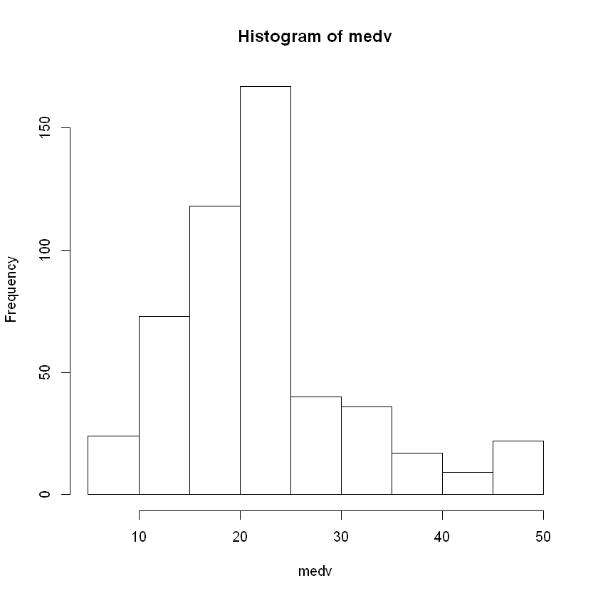

```r
hist(medv)
```

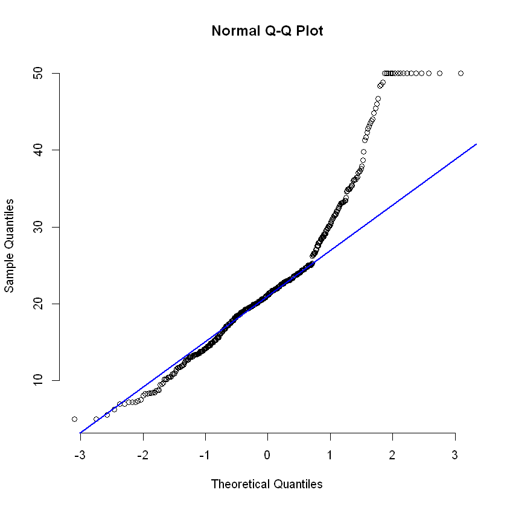

```r
qqnorm(medv,pch=1,frame=FALSE)
qqline(medv,col="blue",lwd=2)
```

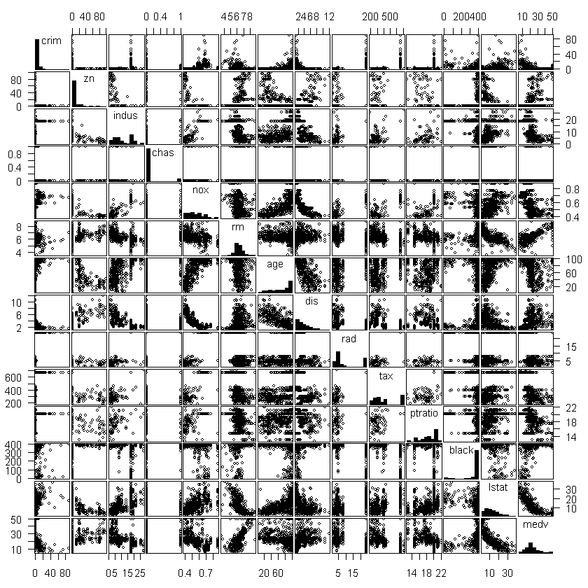

```r
require(gpairs)
gpairs(Boston)
```

Let see how the the `med` price is distributed based on the variable `chas`

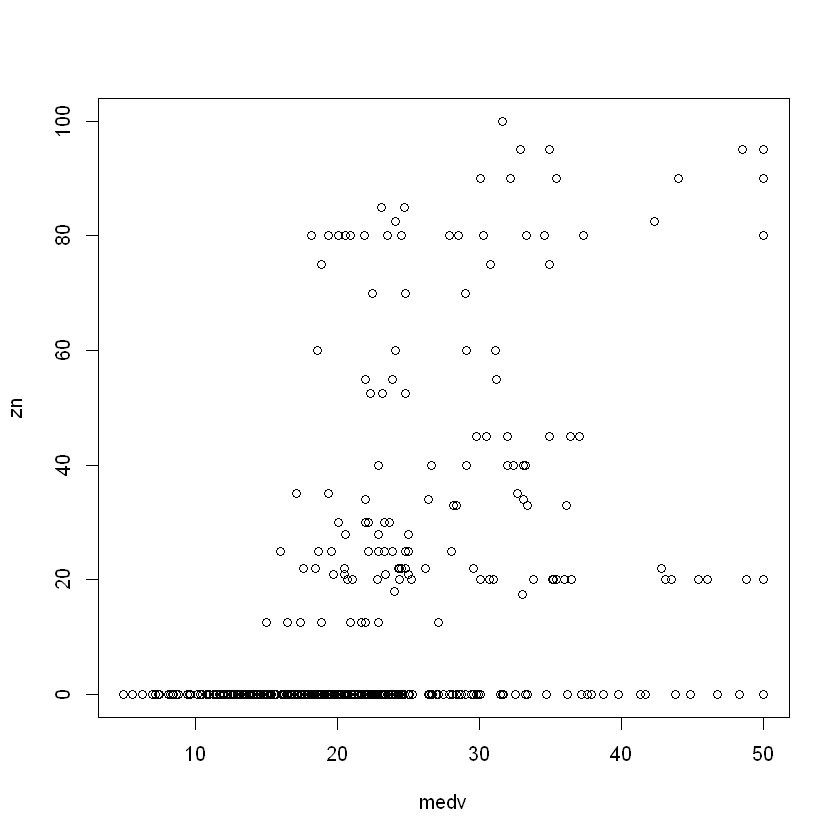

```r
plot(zn~medv)
```

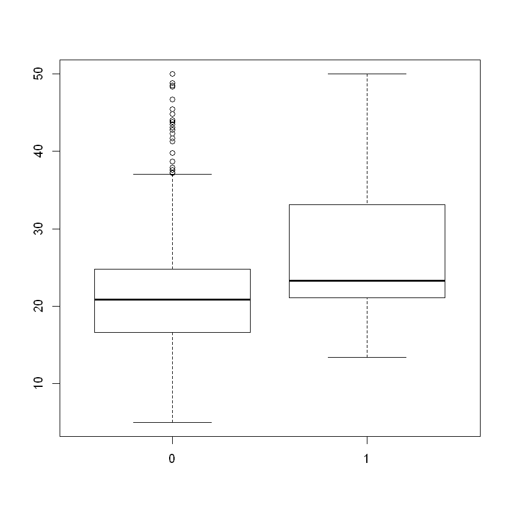

```r
boxplot(medv~chas)
```

```r
crim_dummy =ifelse(crim<mean(crim),1,0)
table(crim_dummy)
```

```
crim_dummy
  0   1
128 378
```

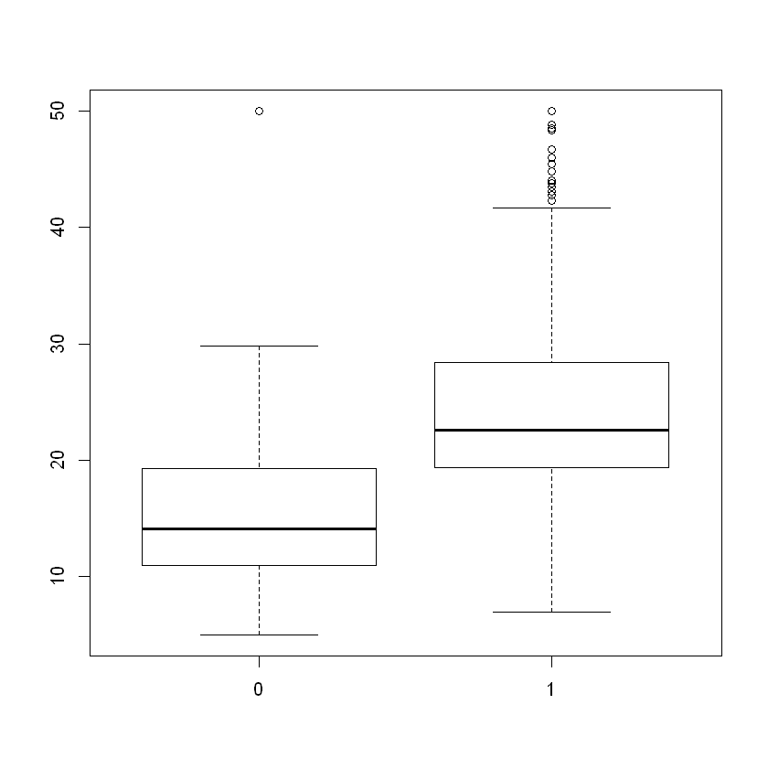

```r
boxplot(medv~crim_dummy)
```

The majority of the `zn` values are zero. That is, many suburbs have no residential land zoned for lots over 25,000 sq ft.

```r
zn
```

1. 18

2. 0

3. 0

4. 0

5. 0

6. 0

7. 12.5

8. 12.5

9. 12.5

10. 12.5

11. 12.5

12. 12.5

13. 12.5

14. 0

15. 0

16. 0

17. 0

18. 0

19. 0

20. 0

21. 0

22. 0

23. 0

24. 0

25. 0

26. 0

27. 0

28. 0

29. 0

30. 0

31. 0

32. 0

33. 0

34. 0

35. 0

36. 0

37. 0

38. 0

39. 0

40. 75

41. 75

42. 0

43. 0

44. 0

45. 0

46. 0

47. 0

48. 0

49. 0

50. 0

51. 21

52. 21

53. 21

54. 21

55. 75

56. 90

57. 85

58. 100

59. 25

60. 25

61. 25

62. 25

63. 25

64. 25

65. 17.5

66. 80

67. 80

68. 12.5

69. 12.5

70. 12.5

71. 0

72. 0

73. 0

74. 0

75. 0

76. 0

77. 0

78. 0

79. 0

80. 0

81. 25

82. 25

83. 25

84. 25

85. 0

86. 0

87. 0

88. 0

89. 0

90. 0

91. 0

92. 0

93. 28

94. 28

95. 28

96. 0

97. 0

98. 0

99. 0

100. 0

101. 0

102. 0

103. 0

104. 0

105. 0

106. 0

107. 0

108. 0

109. 0

110. 0

111. 0

112. 0

113. 0

114. 0

115. 0

116. 0

117. 0

118. 0

119. 0

120. 0

121. 0

122. 0

123. 0

124. 0

125. 0

126. 0

127. 0

128. 0

129. 0

130. 0

131. 0

132. 0

133. 0

134. 0

135. 0

136. 0

137. 0

138. 0

139. 0

140. 0

141. 0

142. 0

143. 0

144. 0

145. 0

146. 0

147. 0

148. 0

149. 0

150. 0

151. 0

152. 0

153. 0

154. 0

155. 0

156. 0

157. 0

158. 0

159. 0

160. 0

161. 0

162. 0

163. 0

164. 0

165. 0

166. 0

167. 0

168. 0

169. 0

170. 0

171. 0

172. 0

173. 0

174. 0

175. 0

176. 0

177. 0

178. 0

179. 0

180. 0

181. 0

182. 0

183. 0

184. 0

185. 0

186. 0

187. 0

188. 45

189. 45

190. 45

191. 45

192. 45

193. 45

194. 60

195. 60

196. 80

197. 80

198. 80

199. 80

200. 95

201. 95

202. 82.5

203. 82.5

204. 95

205. 95

206. 0

207. 0

208. 0

209. 0

210. 0

211. 0

212. 0

213. 0

214. 0

215. 0

216. 0

217. 0

218. 0

219. 0

220. 0

221. 0

222. 0

223. 0

224. 0

225. 0

226. 0

227. 0

228. 0

229. 0

230. 0

231. 0

232. 0

233. 0

234. 0

235. 0

236. 0

237. 0

238. 0

239. 30

240. 30

241. 30

242. 30

243. 30

244. 30

245. 22

246. 22

247. 22

248. 22

249. 22

250. 22

251. 22

252. 22

253. 22

254. 22

255. 80

256. 80

257. 90

258. 20

259. 20

260. 20

261. 20

262. 20

263. 20

264. 20

265. 20

266. 20

267. 20

268. 20

269. 20

270. 20

271. 20

272. 20

273. 20

274. 20

275. 40

276. 40

277. 40

278. 40

279. 40

280. 20

281. 20

282. 20

283. 20

284. 90

285. 90

286. 55

287. 80

288. 52.5

289. 52.5

290. 52.5

291. 80

292. 80

293. 80

294. 0

295. 0

296. 0

297. 0

298. 0

299. 70

300. 70

301. 70

302. 34

303. 34

304. 34

305. 33

306. 33

307. 33

308. 33

309. 0

310. 0

311. 0

312. 0

313. 0

314. 0

315. 0

316. 0

317. 0

318. 0

319. 0

320. 0

321. 0

322. 0

323. 0

324. 0

325. 0

326. 0

327. 0

328. 0

329. 0

330. 0

331. 0

332. 35

333. 35

334. 0

335. 0

336. 0

337. 0

338. 0

339. 0

340. 0

341. 0

342. 35

343. 0

344. 55

345. 55

346. 0

347. 0

348. 85

349. 80

350. 40

351. 40

352. 60

353. 60

354. 90

355. 80

356. 80

357. 0

358. 0

359. 0

360. 0

361. 0

362. 0

363. 0

364. 0

365. 0

366. 0

367. 0

368. 0

369. 0

370. 0

371. 0

372. 0

373. 0

374. 0

375. 0

376. 0

377. 0

378. 0

379. 0

380. 0

381. 0

382. 0

383. 0

384. 0

385. 0

386. 0

387. 0

388. 0

389. 0

390. 0

391. 0

392. 0

393. 0

394. 0

395. 0

396. 0

397. 0

398. 0

399. 0

400. 0

401. 0

402. 0

403. 0

404. 0

405. 0

406. 0

407. 0

408. 0

409. 0

410. 0

411. 0

412. 0

413. 0

414. 0

415. 0

416. 0

417. 0

418. 0

419. 0

420. 0

421. 0

422. 0

423. 0

424. 0

425. 0

426. 0

427. 0

428. 0

429. 0

430. 0

431. 0

432. 0

433. 0

434. 0

435. 0

436. 0

437. 0

438. 0

439. 0

440. 0

441. 0

442. 0

443. 0

444. 0

445. 0

446. 0

447. 0

448. 0

449. 0

450. 0

451. 0

452. 0

453. 0

454. 0

455. 0

456. 0

457. 0

458. 0

459. 0

460. 0

461. 0

462. 0

463. 0

464. 0

465. 0

466. 0

467. 0

468. 0

469. 0

470. 0

471. 0

472. 0

473. 0

474. 0

475. 0

476. 0

477. 0

478. 0

479. 0

480. 0

481. 0

482. 0

483. 0

484. 0

485. 0

486. 0

487. 0

488. 0

489. 0

490. 0

491. 0

492. 0

493. 0

494. 0

495. 0

496. 0

497. 0

498. 0

499. 0

500. 0

501. 0

502. 0

503. 0

504. 0

505. 0

506. 0

```r
zn.zero<-ifelse(zn==0,1,0)
table(zn.zero)
```

```
zn.zero
  0   1
134 372
```

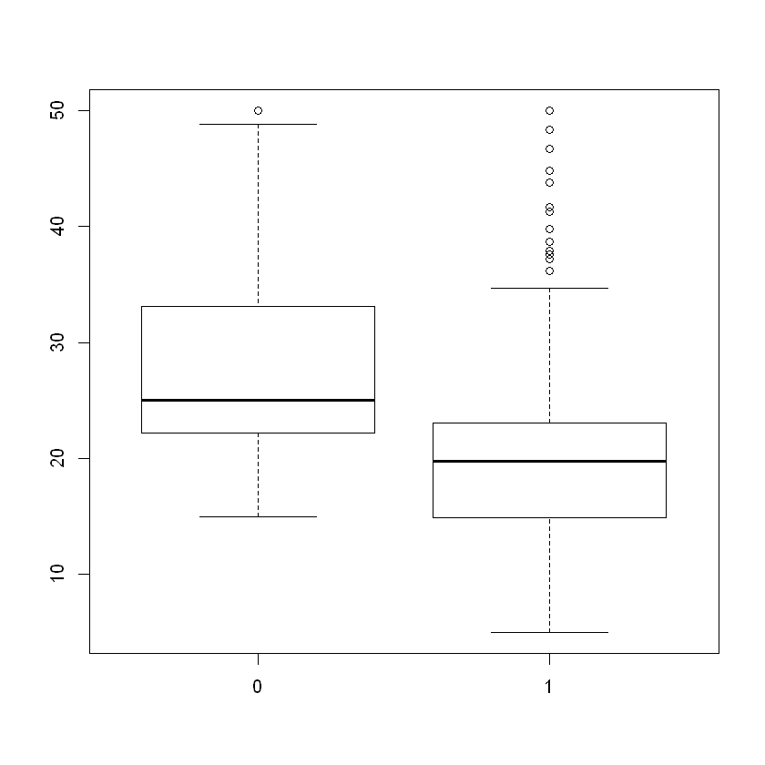

```r
boxplot(medv~zn.zero)
```

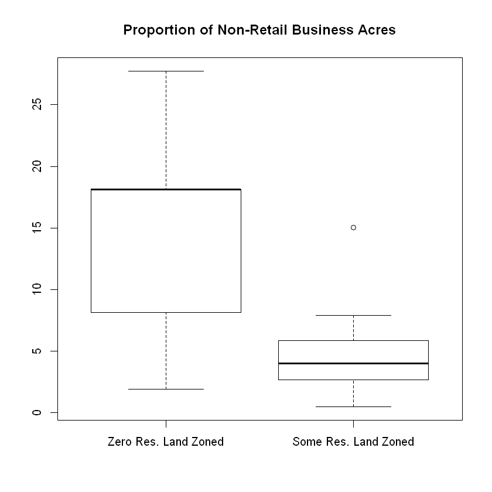

```r
boxplot(indus[zn.zero==1],indus[zn.zero==0],names=c("Zero Res. Land Zoned", "Some Res. Land Zoned"),main="Proportion of Non-Retail Business Acres")
```

The `rm` variable is real-valued (because it is an average). We create a categorical variable `rm2` that rounds the number of rooms to the nearest integer. Let check what are the different values of number of rooms now and how often do each of them occur?

```r
summary(rm)
```

```
   Min. 1st Qu.  Median    Mean 3rd Qu.    Max.
  3.561   5.886   6.208   6.285   6.623   8.780
```

```r
rm2<-round(rm,0)
summary(rm2)
```

```
   Min. 1st Qu.  Median    Mean 3rd Qu.    Max.
  4.000   6.000   6.000   6.267   7.000   9.000
```

```r
sort(unique(rm2))
```

1. 4

2. 5

3. 6

4. 7

5. 8

6. 9

```r
table(rm2)
```

```
rm2
  4   5   6   7   8   9
  5  37 312 125  24   3
```

Now we use graphs to illustrate the differences (for at least three variables) between towns with a pupil-teacher ratio of less than 20 and towns with a pupil-teacher ratio of greater than or equal to 20.

```r
summary(ptratio)
pt.20<-ifelse(ptratio>=20,1,0)

table(pt.20)
```

```
   Min. 1st Qu.  Median    Mean 3rd Qu.    Max.
  12.60   17.40   19.05   18.46   20.20   22.00
```

```
pt.20
  0   1
305 201
```

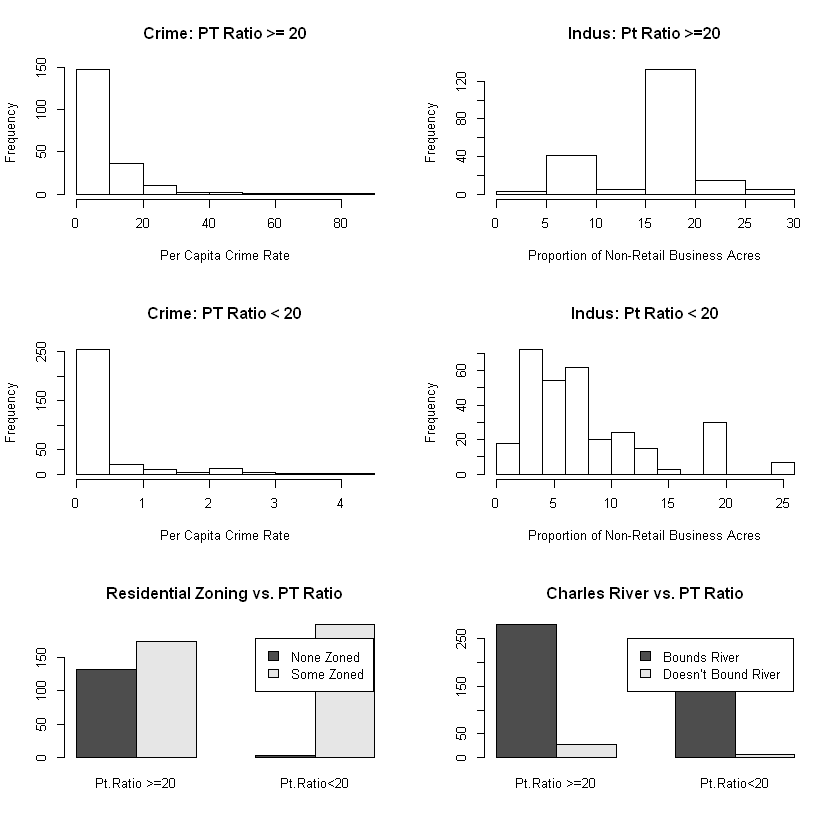

```r
m<-matrix(c(1,2,3,4,5,6),ncol=2)
layout(m)

#Crime Rate:  very different distributions; best looked at with histograms
hist(crim[pt.20==1],xlab="Per Capita Crime Rate",main="Crime: PT Ratio >= 20")
hist(crim[pt.20==0],xlab="Per Capita Crime Rate",main="Crime: PT Ratio < 20")

# Proportion of Residential Land zoned:
#the huge frequency of zn = 0 makes the distribution hard to graph.  Probably more useful to look at the
#table of the two indicator variables (zn = 0 yes/no vs. pt.ratio >= 20  yes/no)
barplot(table(zn.zero,pt.20),beside=T, names=c("Pt.Ratio >=20", "Pt.Ratio<20"),legend.text=c("None Zoned", "Some Zoned"),
        main="Residential Zoning vs. PT Ratio")

#Proportion of Non-retail business acres per town:  very different distributions; best looked at with histograms
hist(indus[pt.20==1],xlab="Proportion of Non-Retail Business Acres",main="Indus: Pt Ratio >=20")
hist(indus[pt.20==0],xlab="Proportion of Non-Retail Business Acres",main="Indus: Pt Ratio < 20")

#Charles River: dummy variable; again we look at the table of the two indicator variables
barplot(table(chas,pt.20),beside=T, names=c("Pt.Ratio >=20", "Pt.Ratio<20"),legend.text=c("Bounds River", "Doesn’t Bound River"),
        main="Charles River vs. PT Ratio")
```

The per capita crime rate appears to be much higher in towns with a greater pupil-teacher ratio. The proportion of non-retail business acres is not distributed that much differently when you look at the actual frequencies excepting a very large peak around 15-20% in the suburbs with a large pupil-teacher ratio. Differences in amount of residential land zoned are apparent in suburbs with a low pupil-teacher ratio. The differences between suburbs on the river and off the river do not appear to depend greatly on the pupil-teacher ratio.

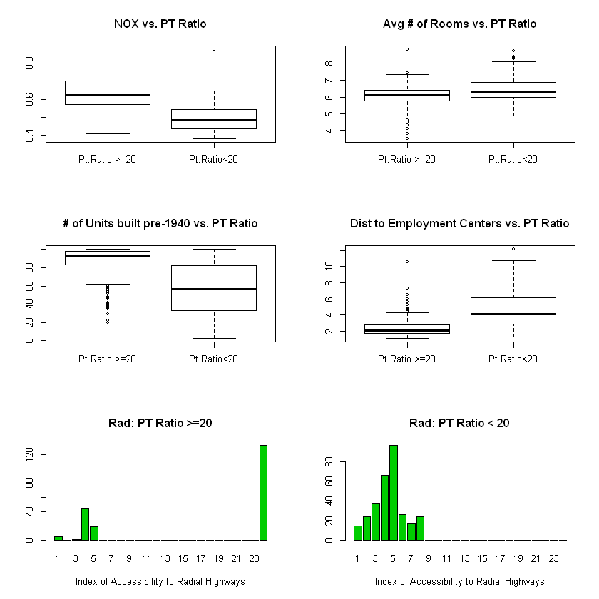

```r
par(mfrow=c(3,2))
#Nitrogen Oxides Concentration (parts per 10 million)
boxplot(nox[pt.20==1],nox[pt.20==0],names=c("Pt.Ratio >=20", "Pt.Ratio<20"),main="NOX vs. PT Ratio")

#Average number of rooms per dwelling
boxplot(rm[pt.20==1],rm[pt.20==0],names=c("Pt.Ratio >=20", "Pt.Ratio<20"),main="Avg # of Rooms vs. PT Ratio")

#Proportion of owner-occupied units built prior to 1940
boxplot(age[pt.20==1],age[pt.20==0],names=c("Pt.Ratio >=20", "Pt.Ratio<20"),main="# of Units built pre-1940 vs. PT Ratio")

#weighted mean of distances to five Boston employment centers
boxplot(dis[pt.20==1],dis[pt.20==0],names=c("Pt.Ratio >=20", "Pt.Ratio<20"),main="Dist to Employment Centers vs. PT Ratio")

# Index of Accessibility to radial highways:  very different distributions but integer-valued
#better to use barplots but we want the ranges to be the same
rad1.freq<-rad2.freq<-rep(0,max(rad,na.rm=T)-min(rad,na.rm=T)+1)
for(i in 1:506){
    if(!is.na(pt.20[i])){
	if(pt.20[i]==1) rad1.freq[rad[i]]<-rad1.freq[rad[i]]+1
	if(pt.20[i]==0) rad2.freq[rad[i]]<-rad2.freq[rad[i]]+1
    }
}
barplot(rad1.freq,xlab="Index of Accessibility to Radial Highways",names=seq(1,24),col=3,main="Rad: PT Ratio >=20")
barplot(rad2.freq,xlab="Index of Accessibility to Radial Highways",names=seq(1,24),col=3,main="Rad: PT Ratio < 20")
```

In suburbs with a higher pupil-teacher ratio, the nitrogen oxides concentration appears to be higher. The average number of rooms doesn’t seem to be dependent on the pupil-teacher ratio; suburbs with a low pupil-teacher ratio perhaps have slightly larger houses. Suburbs with high pupil-teacher ratios have older houses (but note the large number of outliers) and are closet to employment centers. With regards to accessibility to radial highways, there appears to be a group of high pupil-teacher ratio suburbs with better access. Otherwise, the shape of the distributions is not that different (taking into account the frequencies).

The goal is to predict the median value of owner-occupied homes `medv` based on the given predictors.

We start by creating a training set, and fit the tree to the training data

```r
set.seed (1)
train = sample (1: nrow(Boston ), nrow(Boston )/2)
tree.boston =tree(medv∼.,Boston ,subset =train)
summary (tree.boston )
```

```
Regression tree:
tree(formula = medv ~ ., data = Boston, subset = train)
Variables actually used in tree construction:
[1] "lstat" "rm"    "dis"
Number of terminal nodes:  8
Residual mean deviance:  12.65 = 3099 / 245
Distribution of residuals:
     Min.   1st Qu.    Median      Mean   3rd Qu.      Max.
-14.10000  -2.04200  -0.05357   0.00000   1.96000  12.60000
```

Notice that the output of `summary()` indicates that only three of the variables have been used in constructing the tree. In the context of a regression tree, the deviance is simply the sum of squared errors for the tree. We now plot the tree.

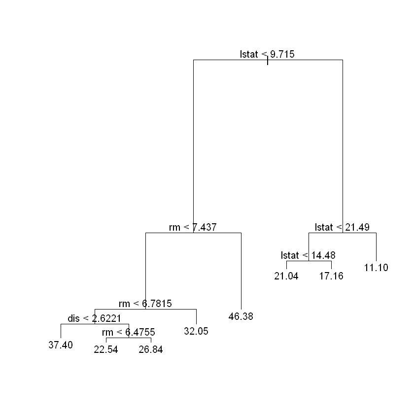

```r
plot(tree.boston )
text(tree.boston ,pretty =0)
```

Now we use the `cv.tree()`function to see whether pruning the tree will improve performance.

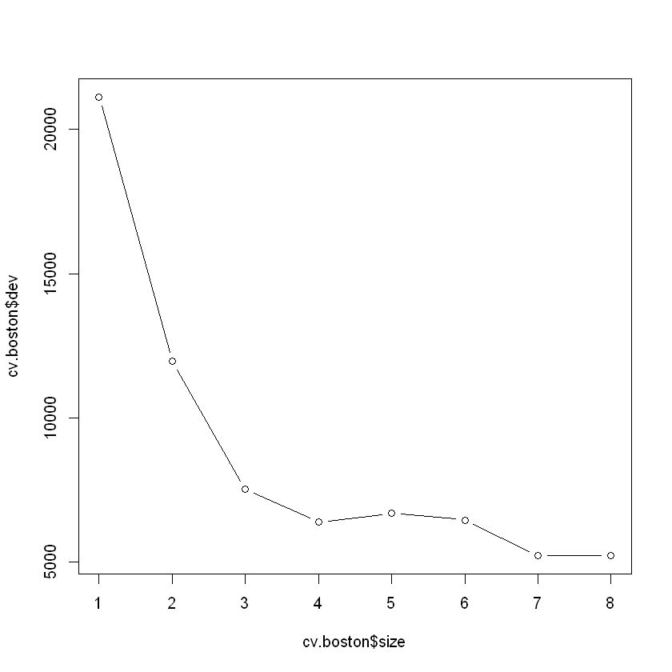

```r
cv.boston =cv.tree(tree.boston )
plot(cv.boston$size ,cv.boston$dev ,type="b")
```

In this case, the most complex tree is selected by cross-validation. However, if we wish to prune the tree, we could do so as follows, using the `prune.tree()` function:

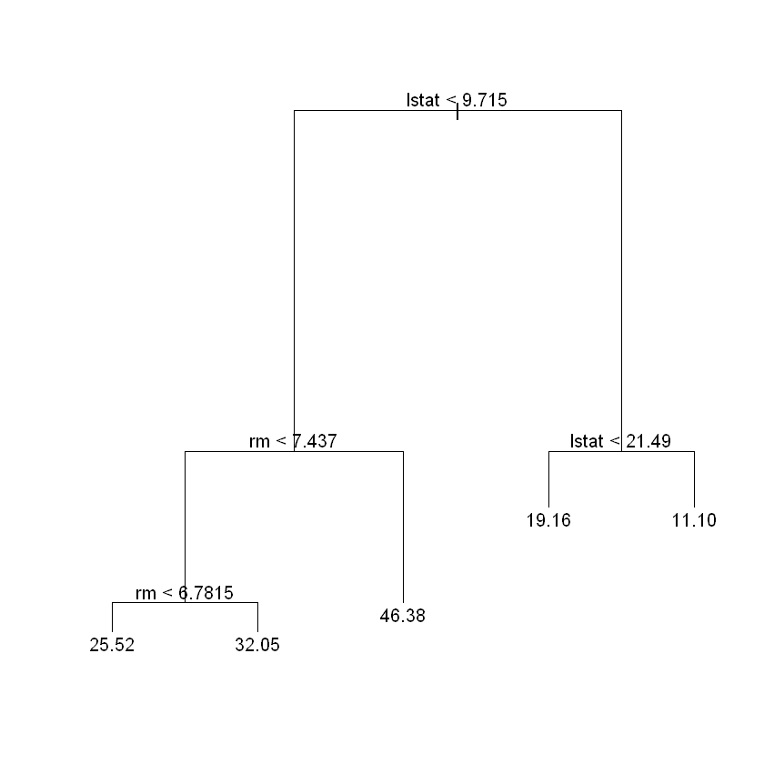

```r
prune.boston =prune.tree(tree.boston ,best =5)
plot(prune.boston )
text(prune.boston ,pretty =0)
```

In keeping with the cross-validation results, we use the unpruned tree to make predictions on the test set.

25.046

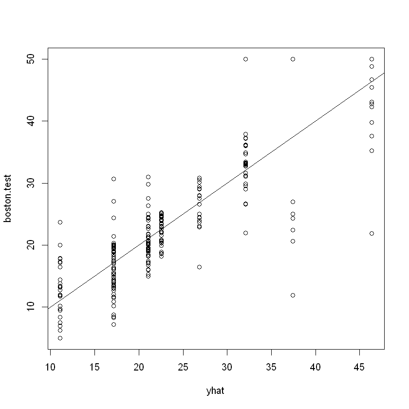

```r
yhat=predict(tree.boston ,newdata =Boston [-train ,])
boston.test=Boston [-train ,"medv"]
plot(yhat ,boston.test)
abline (0,1)
ssr.tree<-(yhat -boston.test)^2
round(mean((yhat -boston.test)^2),3)
```

In other words, the test set MSE associated with the regression tree is $25.05$. The square root of the MSE is therefore around $5.005$, indicating that this model leads to test predictions that are within around $\$5,005$ of the true median home value for the suburb.

## Bagging and Random Forest

Here we apply bagging and random forests to the `Boston` data, using the `randomForest` package in `R`.

Recall that bagging is simply a special case of a random forest with $m = p$. Therefore, the `randomForest()` function can be used to perform both random forests and bagging. We perform bagging as follows:

```r
#install.packages("randomForest")
library (randomForest)
set.seed (1)
bag.boston =randomForest(medv∼.,data=Boston ,subset =train ,
mtry=13, importance =TRUE)
bag.boston
```

```
Call:
 randomForest(formula = medv ~ ., data = Boston, mtry = 13, importance = TRUE,      subset = train)
               Type of random forest: regression
                     Number of trees: 500
No. of variables tried at each split: 13

          Mean of squared residuals: 11.02509
                    % Var explained: 86.65
```

The argument $mtry=13$ indicates that all $13$ predictors should be considered for each split of the tree—in other words, that bagging should be done. How well does this bagged model perform on the test set?

13.4734864318741

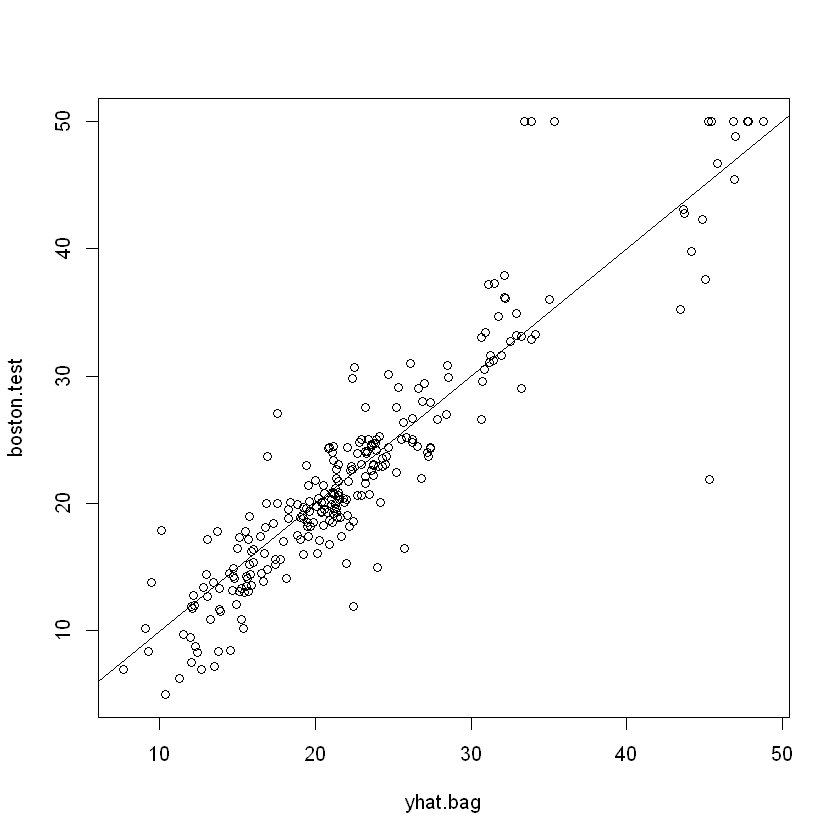

```r
yhat.bag = predict (bag.boston ,newdata =Boston [-train ,])
plot(yhat.bag , boston.test)
abline (0,1)
ssr.bag<-( yhat.bag -boston.test)^2
mean(( yhat.bag -boston.test)^2)
```

```r
bag.boston =randomForest(medv∼.,data=Boston ,subset =train ,
mtry=13, ntree =25)
yhat.bag = predict (bag.boston ,newdata =Boston [-train ,])
mean(( yhat.bag -boston.test)^2)
```

13.4306763829776

Growing a random forest proceeds in exactly the same way, except that we use a smaller value of the `mtry` argument. By default, `randomForest()` uses $p/3$ variables when building a random forest of regression trees. Here we use $mtry = 6$.

```r
set.seed (1)
rf.boston =randomForest(medv∼.,data=Boston ,subset =train ,
mtry=6, importance =TRUE)
yhat.rf = predict (rf.boston ,newdata =Boston [-train ,])
ssr.rf<-( yhat.rf -boston.test)^2
mean(( yhat.rf -boston.test)^2)
```

11.4802165416298

```r
sqrt(11.5)
```

3.39116499156263

Using the `importance()` function, we can view the importance of each variable.

```r
importance (rf.boston )
```

|  | %IncMSE | IncNodePurity |
| --- | --- | --- |
| crim | 12.547772 | 1094.65382 |
| zn | 1.375489 | 64.40060 |
| indus | 9.304258 | 1086.09103 |
| chas | 2.518766 | 76.36804 |
| nox | 12.835614 | 1008.73703 |
| rm | 31.646147 | 6705.02638 |
| age | 9.970243 | 575.13702 |
| dis | 12.774430 | 1351.01978 |
| rad | 3.911852 | 93.78200 |
| tax | 7.624043 | 453.19472 |
| ptratio | 12.008194 | 919.06760 |
| black | 7.376024 | 358.96935 |
| lstat | 27.666896 | 6927.98475 |

Two measures of variable importance are reported. The former is based upon the mean decrease of accuracy in predictions on the out of bag samples when a given variable is excluded from the model. The latter is a measure of the total decrease in node impurity that results from splits over that variable, averaged over all trees. In the case of regression trees, the node impurity is measured by the training RSS. Plots of these importance measures can be produced using the `varImpPlot()` function.

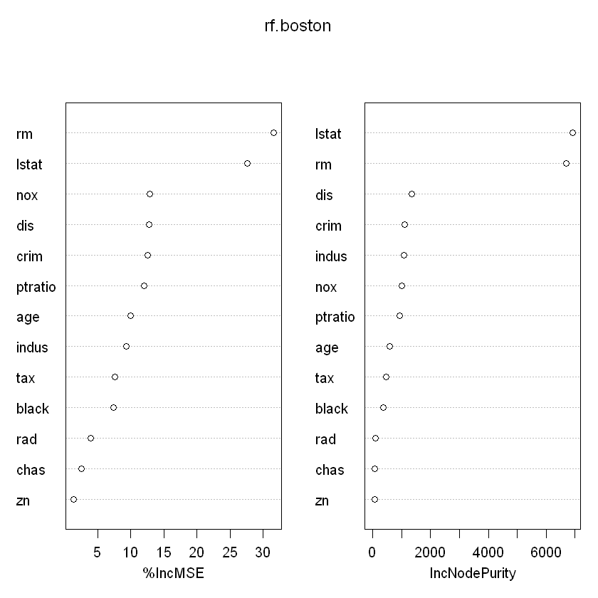

```r
varImpPlot (rf.boston )
```

The results indicate that across all of the trees considered in the random forest, the wealth level of the community (`lstat`) and the house size (`rm`) are by far the two most important variables.

Now let run linear model and compare tree based models with the linear model

```r
lm.boston<-lm(formula = medv ~ crim + chas + nox + rm + dis + rad + tax +ptratio + black + lstat, data = Boston)
```

```r
yhat.lm = predict (lm.boston ,newdata =Boston [-train ,])
```

```r
ssr.lm<-( yhat.lm -boston.test)^2
```

```r
mean(ssr.lm)
```

24.6497637242437

```r
ssr.tree= rnorm(100,15,8)
ssr.bag= rnorm(100,13,5)
ssr.rf= rnorm(100,10,4)
ssr.lm= rnorm(100,15,13)
```

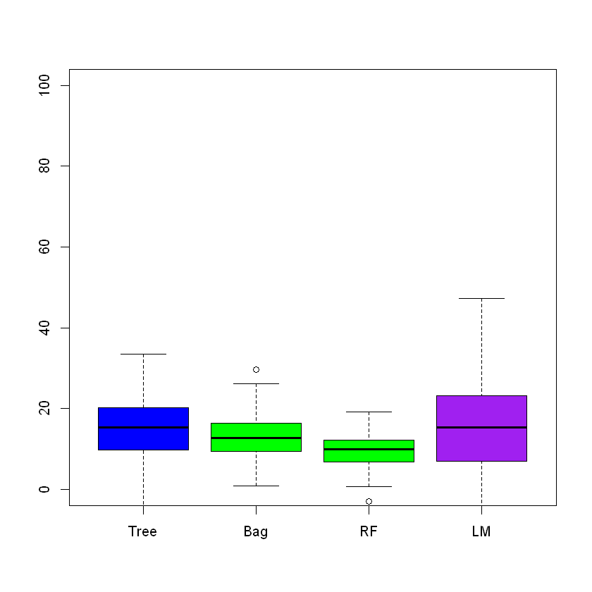

```r
boxplot(ssr.tree,ssr.bag,ssr.rf,ssr.lm,names=c("Tree","Bag","RF","LM"),ylim=c(0,100),col=c("blue","green","green","purple"))
```